# State Report Cards

Jose Figueroa

06/02/20

# Data Exploration

There are two main types of data we work with on COVID**MINDER**. GGplots work with time series data, and Leaflet Plots work with static data points for each state.

## ggplot datasets

```r
covid_TS_counties_long.cases %>% str() %>% print() # County Level data
```

```
tibble [256,683 × 14] (S3: spec_tbl_df/tbl_df/tbl/data.frame)
 $ countyFIPS: num [1:256683] 6085 6085 6085 6085 53033 ...
 $ County    : chr [1:256683] "Santa Clara" "Santa Clara" "Santa Clara" "Santa Clara" ...
 $ State     : chr [1:256683] "CA" "CA" "CA" "CA" ...
 $ stateFIPS : num [1:256683] 6 6 6 6 53 6 53 6 53 6 ...
 $ date      : POSIXct[1:256683], format: "2020-02-26" "2020-02-27" "2020-02-28" "2020-02-29" ...
 $ cases     : num [1:256683] 7 7 9 13 6 13 9 18 14 20 ...
 $ deaths    : num [1:256683] 2 2 2 2 1 2 1 2 5 2 ...
 $ population: num [1:256683] 1927852 1927852 1927852 1927852 2252782 ...
 $ p_cases   : num [1:256683] 0.363 0.363 0.467 0.674 0.266 ...
 $ p_deaths  : num [1:256683] 0.1037 0.1037 0.1037 0.1037 0.0444 ...
 $ diff      : num [1:256683] 7 0 2 4 6 0 3 5 5 2 ...
 $ p_diff    : num [1:256683] 0.363 0 0.104 0.207 0.266 ...
 $ d_diff    : num [1:256683] 2 0 0 0 1 0 0 0 4 0 ...
 $ p.d_diff  : num [1:256683] 0.1037 0 0 0 0.0444 ...
 - attr(*, "spec")=
  .. cols(
  ..   countyFIPS = col_double(),
  ..   County = col_character(),
  ..   State = col_character(),
  ..   stateFIPS = col_double(),
  ..   date = col_datetime(format = ""),
  ..   cases = col_double(),
  ..   deaths = col_double(),
  ..   population = col_double(),
  ..   p_cases = col_double(),
  ..   p_deaths = col_double(),
  ..   diff = col_double(),
  ..   p_diff = col_double(),
  ..   d_diff = col_double(),
  ..   p.d_diff = col_double()
  .. )
NULL
```

```r
covid_TS_state_long.cases %>% str() %>% print() # State Level data
```

```
tibble [6,497 × 11] (S3: spec_tbl_df/tbl_df/tbl/data.frame)
 $ State     : chr [1:6497] "AK" "AK" "AK" "AK" ...
 $ date      : POSIXct[1:6497], format: "2020-03-17" "2020-03-18" "2020-03-19" "2020-03-20" ...
 $ cases     : num [1:6497] 6 6 10 13 15 23 37 42 59 69 ...
 $ deaths    : num [1:6497] 0 0 0 0 0 0 0 0 1 1 ...
 $ population: num [1:6497] 731545 731545 731545 731545 731545 ...
 $ p_cases   : num [1:6497] 0.82 0.82 1.37 1.78 2.05 ...
 $ p_deaths  : num [1:6497] 0 0 0 0 0 ...
 $ diff      : num [1:6497] 6 0 4 3 2 8 14 5 17 10 ...
 $ p_diff    : num [1:6497] 0.82 0 0.547 0.41 0.273 ...
 $ d_diff    : num [1:6497] 0 0 0 0 0 0 0 0 1 0 ...
 $ p.d_diff  : num [1:6497] 0 0 0 0 0 ...
 - attr(*, "spec")=
  .. cols(
  ..   State = col_character(),
  ..   date = col_datetime(format = ""),
  ..   cases = col_double(),
  ..   deaths = col_double(),
  ..   population = col_double(),
  ..   p_cases = col_double(),
  ..   p_deaths = col_double(),
  ..   diff = col_double(),
  ..   p_diff = col_double(),
  ..   d_diff = col_double(),
  ..   p.d_diff = col_double()
  .. )
NULL
```

```r
covid_TS_US_long.cases %>% str() %>% print() # National Data
```

```
tibble [171 × 9] (S3: spec_tbl_df/tbl_df/tbl/data.frame)
 $ date    : POSIXct[1:171], format: "2020-01-27" "2020-01-28" "2020-01-29" "2020-01-30" ...
 $ cases   : num [1:171] 6 6 7 7 8 9 9 11 11 11 ...
 $ deaths  : num [1:171] 0 0 0 0 0 0 0 0 0 0 ...
 $ p_cases : num [1:171] 0.00183 0.00183 0.00213 0.00213 0.00244 ...
 $ p_deaths: num [1:171] 0 0 0 0 0 0 0 0 0 0 ...
 $ diff    : num [1:171] 6 0 1 0 1 1 0 2 0 0 ...
 $ p_diff  : num [1:171] 0.001828 0 0.000305 0 0.000305 ...
 $ d_diff  : num [1:171] 0 0 0 0 0 0 0 0 0 0 ...
 $ p.d_diff: num [1:171] 0 0 0 0 0 0 0 0 0 0 ...
 - attr(*, "spec")=
  .. cols(
  ..   date = col_datetime(format = ""),
  ..   cases = col_double(),
  ..   deaths = col_double(),
  ..   p_cases = col_double(),
  ..   p_deaths = col_double(),
  ..   diff = col_double(),
  ..   p_diff = col_double(),
  ..   d_diff = col_double(),
  ..   p.d_diff = col_double()
  .. )
NULL
```

Metadata: * countyFIPS - Unique integer ID identifying a United States County. The first 2 numbers can be processed into StateFips * County - Name of the county. Not Unique. * State - Two letter state initial. Uniquely Identifies state. * stateFIPS - Unique integer ID identifying a United States state. * date - Date in which row data was reported. Please note unix date_time format. * cases - Overall COVID-19 cases as of reported date. * deaths - Overall COVID-19 deaths as of reported date. * p_cases - Overall COVID-19 cases per 100k as of reported date. * p_deaths - Overall COVID-19 deaths per 100k as of reported date. * diff - Change in COVID-19 cases from previous day. Generally >= 0, though some data report discrepancies may generate negatives. * p_diff - Change in COVID-19 cases per 100k from previous day. Generally >= 0, though some data report discrepancies may generate negatives. * d_diff - Change in COVID-19 deaths from previous day. Generally >= 0, though some data report discrepancies may generate negatives. * p.d_diff - Change in COVID-19 deaths per 100k from previous day. Generally >= 0, though some data report discrepancies may generate negatives.

In `covid_TS_counties_long.cases`, a row is uniquely identified by its `countyFIPS` and `date` columns. In `covid_TS_state_long.cases`, a row is uniquely identified by its `State` and `date` columns. In `covid_TS_US_long.cases`, a row is uniquely identified by its `date` column.

Our GGplot functions access these dataframes directly, to report data at the state or national level. They can be used to plot any non-identifying column. Command+Click on the functions to view the code.

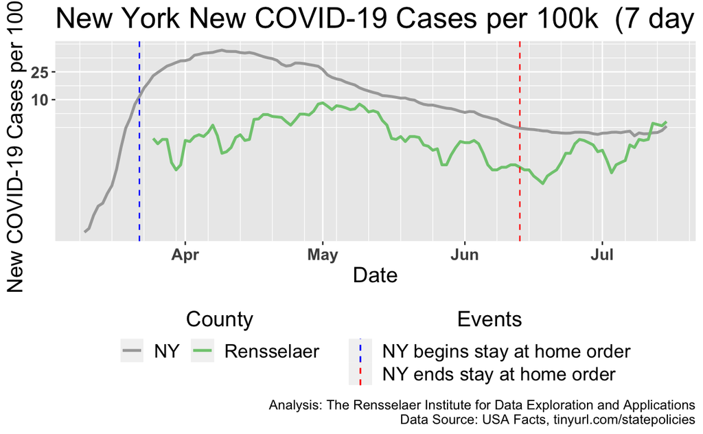

```r
ggplot.state("NY","p_diff", counties = c("Rensselaer"))
```

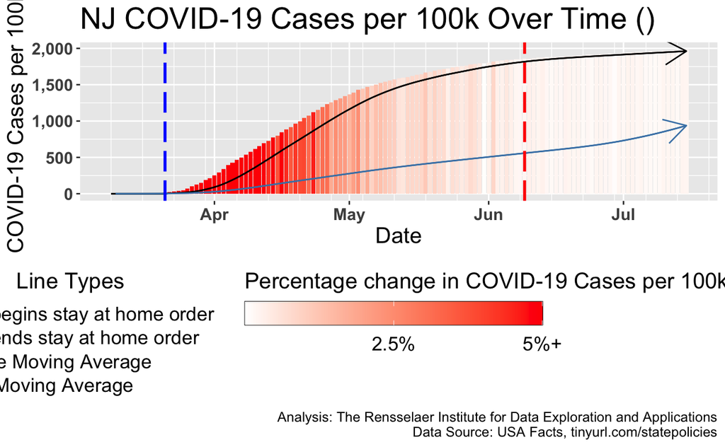

```r
ggbar.overall("NJ", "p_cases")
```

```
Column `State`/`abr` joining character vector and factor, coercing into character vectorScale for 'colour' is already present. Adding another scale for 'colour', which will replace the existing scale.
```

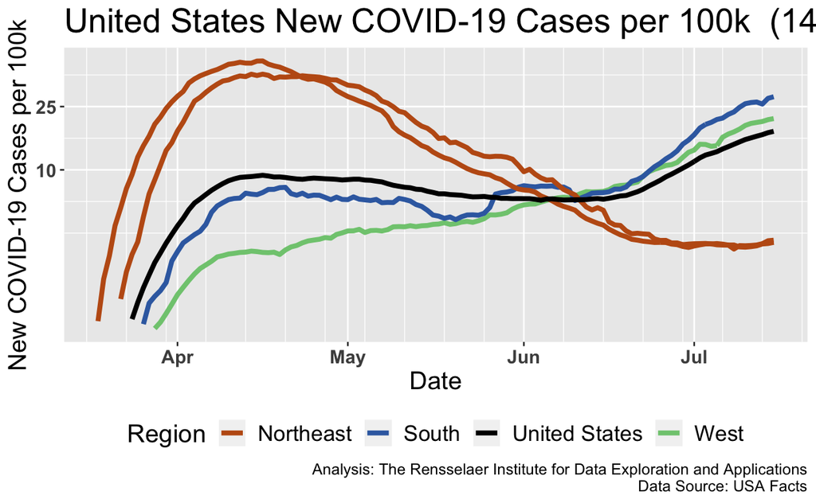

```r
ggplot.US("p_diff", selected.states = c("NY", "CA", "NJ", "GA"), moving.avg.window = 14)
```

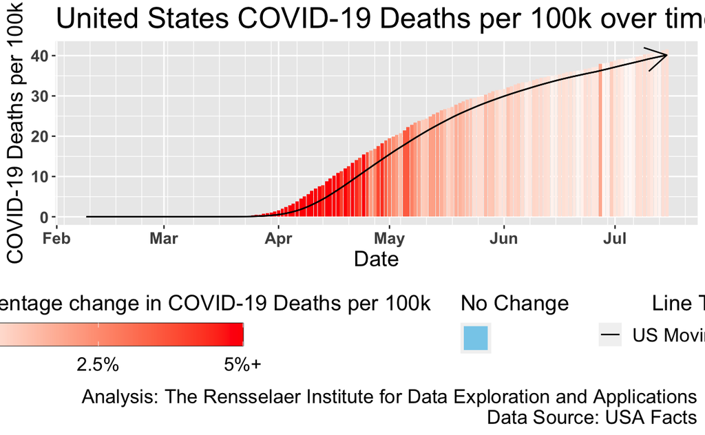

```r
ggbar.US("p_deaths")
```

## leaflet datasets

```r
todays.case.data %>% str() %>% print()
```

```
tibble [3,142 × 21] (S3: spec_tbl_df/tbl_df/tbl/data.frame)
 $ countyFIPS              : num [1:3142] 1001 1003 1005 1007 1009 ...
 $ County                  : chr [1:3142] "Autauga" "Baldwin" "Barbour" "Bibb" ...
 $ State                   : chr [1:3142] "AL" "AL" "AL" "AL" ...
 $ Cases                   : num [1:3142] 756 1518 441 242 389 ...
 $ population              : num [1:3142] 55869 223234 24686 22394 57826 ...
 $ Mortality               : num [1:3142] 19 13 3 2 1 11 31 6 32 7 ...
 $ name                    : chr [1:3142] "Alabama" "Alabama" "Alabama" "Alabama" ...
 $ Case_rate               : num [1:3142] 0.01353 0.0068 0.01786 0.01081 0.00673 ...
 $ Case_rate_ldi           : num [1:3142] 0.192 -0.4961 0.4698 -0.0329 -0.5069 ...
 $ Mortality_rate          : num [1:3142] 3.40e-04 5.82e-05 1.22e-04 8.93e-05 1.73e-05 ...
 $ Mortality_rate_ldi      : num [1:3142] -0.258 -2.023 -1.287 -1.595 -3.237 ...
 $ Diabetes_rate           : num [1:3142] 0.099 0.085 0.157 0.133 0.149 0.224 0.169 0.156 0.175 0.122 ...
 $ Diabetes_rate_ldi       : num [1:3142] 0.0843 -0.0682 0.5454 0.3795 0.4931 ...
 $ Obesity_rate            : num [1:3142] 0.33 0.31 0.42 0.38 0.34 0.37 0.43 0.39 0.4 0.35 ...
 $ Obesity_rate_ldi        : num [1:3142] 0.05289 -0.00963 0.29405 0.19397 0.08274 ...
 $ CRD Mortality_rate      : num [1:3142] 0.000818 0.000543 0.000698 0.000845 0.00087 ...
 $ CRD Mortality_rate_ldi  : num [1:3142] 0.4354 0.0254 0.2771 0.4679 0.4977 ...
 $ Daily Case_rate         : num [1:3142] 0.000268 0.000296 0.000434 0.000262 0.000314 ...
 $ Daily Mortality_rate    : num [1:3142] 1.53e-05 1.92e-06 5.79e-06 6.38e-06 0.00 ...
 $ Daily Mortality_rate_ldi: num [1:3142] 1.93 -0.148 0.955 1.052 -5 ...
 $ Daily Case_rate_ldi     : num [1:3142] 0.34 0.436 0.82 0.313 0.495 ...
NULL
```

```r
states %>% str() %>% print()
```

```
'data.frame':   51 obs. of  61 variables:
 $ FIPS                              : chr  "04" "05" "06" "08" ...
 $ NAME                              : chr  "Arizona" "Arkansas" "California" "Colorado" ...
 $ hosp_beds_ldi                     : num  -0.5056 -0.0126 -0.5534 -0.5426 -0.465 ...
 $ Testing_rate                      : num  0.1151 0.1357 0.1555 0.0815 0.169 ...
 $ Daily Testing_rate                : num  0.00219 0.00188 0.00318 0.001 0.00345 ...
 $ tests_per_1000                    : num  115.1 135.7 155.5 81.5 169 ...
 $ Population                        : num  6392017 2915918 37253956 5029196 3574097 ...
 $ Testing_rate_ldi                  : num  -0.1792 -0.0146 0.1214 -0.5244 0.2047 ...
 $ Daily Testing_rate_ldi            : num  -0.111 -0.266 0.259 -0.895 0.343 ...
 $ at_risk_ldi                       : num  0.05353 0.22787 -0.16412 -0.18994 -0.00414 ...
 $ older_at_risk_ldi                 : num  0.0151 -0.2607 0.01 0.1025 0.2103 ...
 $ Heart Disease Mortality_rate      : num  0.00139 0.00223 0.00146 0.00128 0.00148 ...
 $ cardio_deaths_p_Black_Non_Hispanic: num  175 265 213 173 163 ...
 $ Heart Disease Mortality_rate_ldi  : num  -0.194 0.281 -0.146 -0.272 -0.131 ...
```

[output cut: 48 more lines]

Any datapoint with a log disparity index (LDI) can be generated into a leaflet plot. `geo.plot` is currently built to visualize variables that have the following columns: * `feature name`_rate * `feature name`_rate_ldi

*Note: Legend depends on CSS stylings to have flat visualization.*

```r
geo.plot("NY", "Mortality")
```

[interactive chart not shown]

```r
geo.plot("US", "Testing", reverse = T)
```

[interactive chart not shown]

# Tab panel example

Here is a small application with a singular tabpanel in a navbar setup. To add to covidminder, simply add a tab panel where it is desired.

```r
ui <- tagList(
    tags$head(includeCSS("www/style.css")),
    navbarPage(
    title = tags$div(class = "title-text", "COVIDMINDER"),
    id = "tab",
    tabPanel( # Separate Tab Panel
      title = "Example Panel 1",
      value = "example", # Should be unique and appended to tabs list in the server code
      fluidRow(tags$h1("Daily New York Cases/100k")),
      fluidRow(plotOutput("ny_output"))
    ),
    navbarMenu( # List of Tab Panels in drop down menu
      title = "Example Menu 1",
               tabPanel(
                 title = "Example Panel 2",
                 value = "example2",
                 fluidRow(tags$h1("New York Testing")),
                 fluidRow(leafletOutput("ny_output2"))
               ))
    #,
    #tabPanel(...),
    #navbarMenu(tabPanel(...), tabPanel(...)),
    #tabPanel(...)
  )
)
```

```r
server <- function(input, output) {
  output$ny_output <- renderPlot({
    ggplot.state(selected.state = "NY",
                 y.value = "p_diff",
                 moving.avg.window = 14,
                 counties = c("Rensselaer", "New York City", "Albany", "Nassau", "Erie"),
                 remove.title = T)
  })

  output$ny_output2 <- renderLeaflet({
    geo.plot(state.choice = "NY",
             feature = "Daily Testing",
             reverse = T)
  })
}
```

```r
shinyApp(ui = ui, server = server)
```

```
Listening on http://127.0.0.1:4188
```

```
NA
```